# Road Accidents in UK (2015)

## Data Mining II

*Joel Sousa up201103870*

*Luis Moreira up201102786*

*Pavel Kajaba up201610230*

*Pedro Osório up201102741*

#### Introduction

As we all may know thousands of people die every year due to Road Accidents and Accident’s Data has been growing exponentional. Our job as Data Mining Engineers is to find as many rules as we can that better describes the main reasons that tell us: “Why are those Accidents happening?”. To accomplish that task we’re going to use the Apriori algorithm and we’re going to set minsup (minimum support) and minconf (minimum confidence) values to generate rules and we’re going to choose them looking for lift values grater than 1,1. It’s very important to do this kind of work as we might find solutions to avoid so many accidents that are happening in the United Kingdom (2015).

#### Pratical Work

##### Data Mining

Our Data Set contains multiples instances related to Accident’s information. After an extended analysis and removing a lot of, what we’ve considered, unnecessary data, we can present our final result. Our final Data Set has information related to, for example, *Date*: We can observe that had happened more accidents during the 3rd Trimester.

```r
head(summary(data_set))
```

```
##  Accident_Severity Number_of_Vehicles Number_of_Casualties
##  Fatal  :  1616    1  :41116          1  :109395
##  Serious: 20038    2  :84615          2  : 21138
##  Slight :118402    3  :11064          3  :  6052
##                    >=4: 3261          4  :  2141
##                                       >=5:  1330
##
##             Date          Day_of_Week           Time
##  1st Trimester:32824   Friday   :22374   00H - 06H: 7382
##  2nd Trimester:34373   Monday   :20032   06H - 12H:39805
##  3rd Trimester:36442   Saturday :18114   12H - 18H:60134
##  4th Trimester:36417   Sunday   :15258   18H - 24H:32717
##                        Thursday :21479   NA's     :   18
##                        Tuesday  :21431
##                Road_Type            Speed_limit    Light_Conditions
##  Dual carriageway   :  2873   0mph - 40mph:93920   Darkness: 37448
##  Other              :107328   >40mph      :46136   Daylight:102608
##  Roundabout         :  9589
##  Single\ncarriageway: 20266
##
##
##               Weather_Conditions Road_Surface_Conditions
##  Fine no high winds    :113949   Dry  :101355
##  Other                 : 10548   Other:  2180
##  Raining no high\nwinds: 15559   Wet  : 36237
##                                  NA's :   284
##
##
##                               Special_Conditions_at_Site
##  Auto signal part defective                :    51
##  Auto traffic signal - out                 :   212
##  None                                      :136823
##  Other                                     :  2704
##  Road sign or marking defective or obscured:   160
##  NA's                                      :   106
```

Now we’re going to apply the Aprior algorithm on our Data Set and the following rules were obtained. The result is a set of **2724 rules**. We’re about to reduce the size of this set by adjusting minsup and minconf values.

```r
rules <- apriori(data_set,parameter=list(support=0.2, confidence=0.5))
rules
```

First we’re going to plot our data set and then analyse which range of confidence and support have the better rules (with a good lift value).

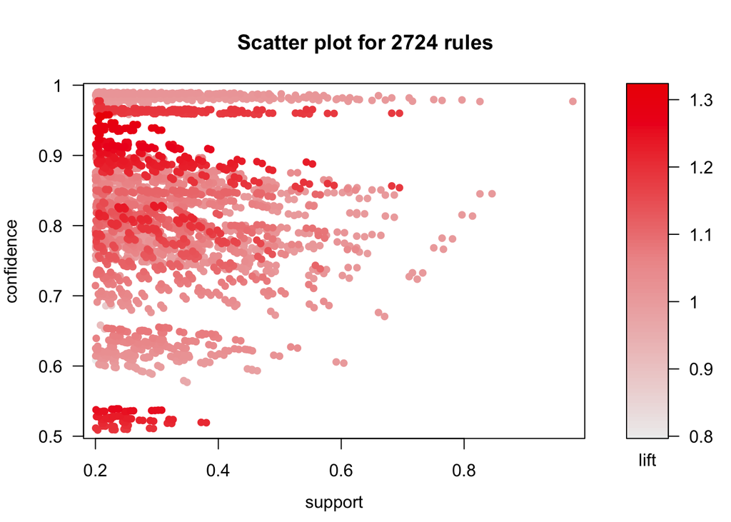

```r
plot(rules)
```

As we can observe, best rules have minsup values between [0.2 , 0.3], and minconf values between [0.8 , 1.0]. So, now we’re about to adjust our aprior algorithm by changing minsup and minconf values, and also by adding an extra option: **minlen = 3** . This option allow us to choose rules with a minimum length of 3.

```r
rules <- apriori(data_set,parameter=list(support=0.25, confidence=0.85, minlen=3))
```

As we can see we’ve obtained a set of 653 rules, even though a lot less then 2724 we still need to adjust the apriori algorithm a little bit more. First things first, lets analyse our new set of rules by using a plot.

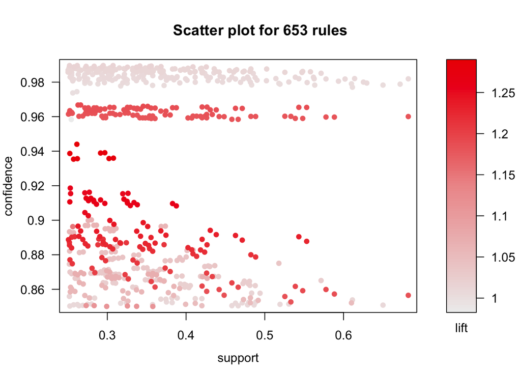

```r
plot(rules)
```

As we can observe, best rules have minsup values between [0.2 , 0.3], and minconf values between [0.9 , 1.0]. So, now we’re about to adjust our aprior algorithm by changing minsup and minconf values.

```r
rules <- apriori(data_set,parameter=list(support=0.25, confidence=0.9, minlen=3))
```

We’ve obtained a set of 355 rules and we’re going to reduce this number by removing all redundant rules: if we have *{A,B,C} => {D}* and *{A,B} => {D}*, we can remove the second one because it derivates from the first one.

```r
rules<-rules[!is.redundant(rules)]
summary(rules)
```

[figure not shown]

So let’s filter our rule set.

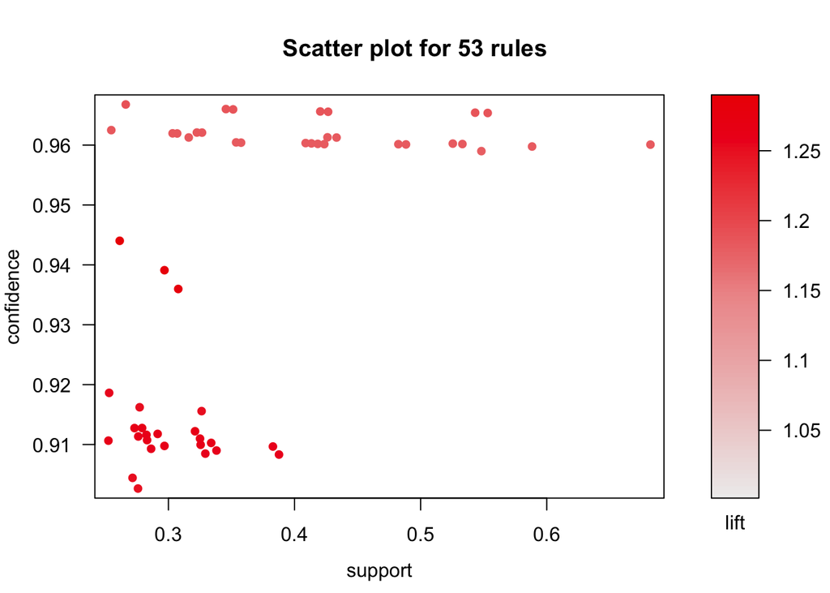

```r
subrules <- rules[quality(rules)$lift >= 1.1]
summary(subrules)
plot(subrules)
```

Only 53 rules are present in our rule set and all of them are good one with a good lift value. Let’s use a plot using support and lift instead of support and confidence (lift on y-axis).

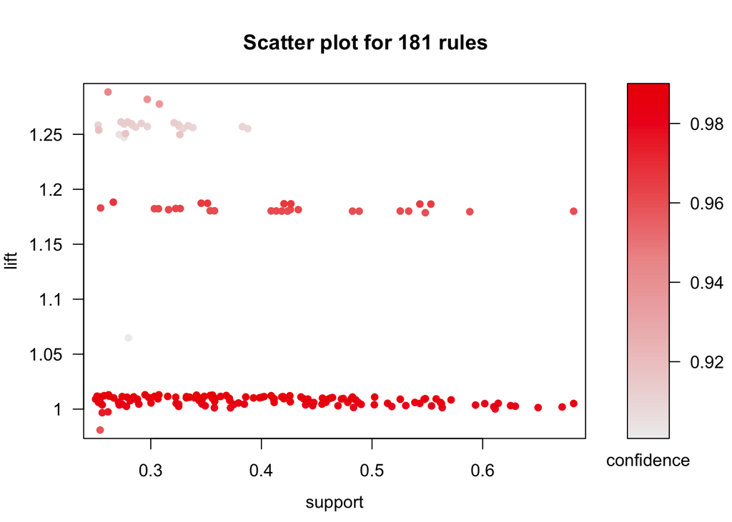

```r
plot(rules, measure=c("support", "lift"), shading="confidence")
```

Now we’re about to order our rule set by lift and plot it using a *Two-key plot*. Here order represents, for example, the number of items in a rule.

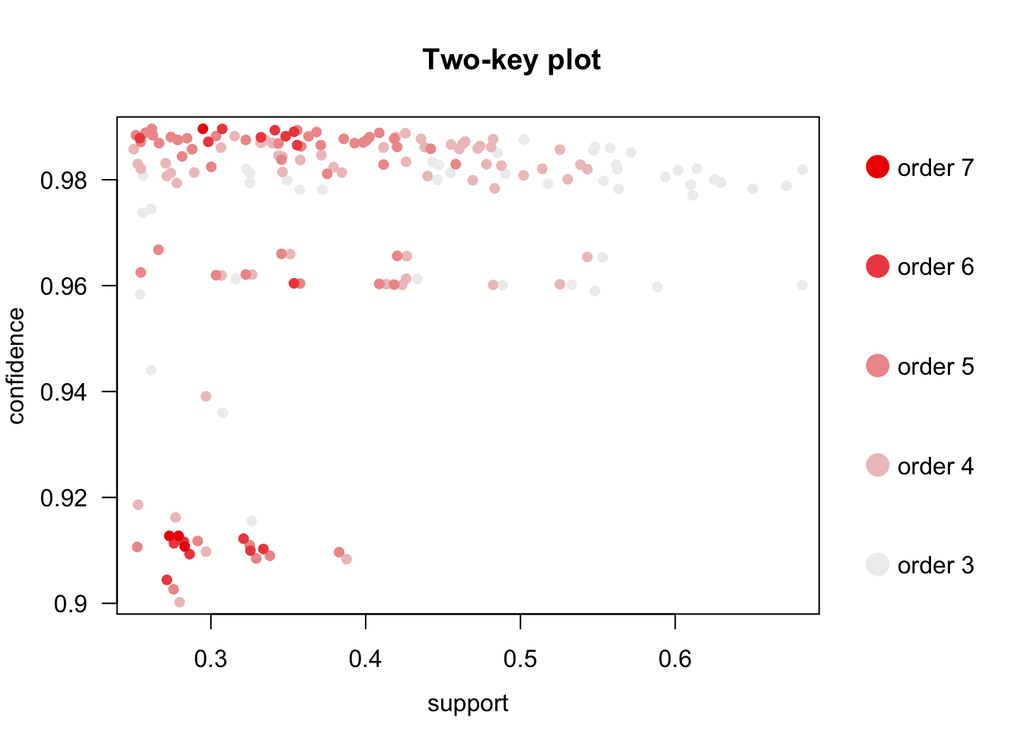

```r
plot(rules, shading="order", control=list(main = "Two-key plot"))
```

After using a matrix plot method using the following command,*plot(subrules, method=“matrix”, measure=“lift”)*, we’re able to obtain an output of our rule set:

Itemsets in Antecedent (LHS)

[1] “{Time=06H - 12H,Special_Conditions_at_Site=None}”  
[2] “{Time=12H - 18H,Road_Surface_Conditions=Dry}”  
[3] “{Time=12H - 18H,Weather_Conditions=Fine no high winds}”  
[4] “{Number_of_Vehicles=2,Road_Surface_Conditions=Dry}”  
[5] “{Speed_limit=0mph - 40mph,Road_Surface_Conditions=Dry}”  
[6] “{Light_Conditions=Daylight,Road_Surface_Conditions=Dry}”  
[7] “{Road_Type=Other,Road_Surface_Conditions=Dry}”  
[8] “{Number_of_Casualties=1,Road_Surface_Conditions=Dry}”  
[9] “{Accident_Severity=Slight,Road_Surface_Conditions=Dry}”  
[10] “{Road_Surface_Conditions=Dry,Special_Conditions_at_Site=None}”  
[11] “{Time=12H - 18H,Weather_Conditions=Fine no high winds,Road_Surface_Conditions=Dry}”  
[12] “{Time=12H - 18H,Light_Conditions=Daylight,Weather_Conditions=Fine no high winds}”  
[13] “{Time=12H - 18H,Road_Type=Other,Weather_Conditions=Fine no high winds}”  
[14] “{Accident_Severity=Slight,Time=12H - 18H,Weather_Conditions=Fine no high winds}”  
[15] “{Number_of_Vehicles=2,Speed_limit=0mph - 40mph,Road_Surface_Conditions=Dry}”  
[16] “{Number_of_Vehicles=2,Light_Conditions=Daylight,Road_Surface_Conditions=Dry}”  
[17] “{Number_of_Vehicles=2,Road_Type=Other,Road_Surface_Conditions=Dry}”  
[18] “{Number_of_Vehicles=2,Road_Surface_Conditions=Dry,Special_Conditions_at_Site=None}”  
[19] “{Speed_limit=0mph - 40mph,Light_Conditions=Daylight,Weather_Conditions=Fine no high winds}”  
[20] “{Road_Type=Other,Speed_limit=0mph - 40mph,Road_Surface_Conditions=Dry}”  
[21] “{Accident_Severity=Slight,Speed_limit=0mph - 40mph,Road_Surface_Conditions=Dry}”  
[22] “{Speed_limit=0mph - 40mph,Road_Surface_Conditions=Dry,Special_Conditions_at_Site=None}”  
[23] “{Road_Type=Other,Light_Conditions=Daylight,Road_Surface_Conditions=Dry}”  
[24] “{Light_Conditions=Daylight,Road_Surface_Conditions=Dry,Special_Conditions_at_Site=None}”  
[25] “{Road_Type=Other,Road_Surface_Conditions=Dry,Special_Conditions_at_Site=None}”  
[26] “{Accident_Severity=Slight,Time=12H - 18H,Light_Conditions=Daylight,Weather_Conditions=Fine no high winds}”  
[27] “{Time=12H - 18H,Light_Conditions=Daylight,Weather_Conditions=Fine no high winds,Special_Conditions_at_Site=None}”  
[28] “{Number_of_Vehicles=2,Road_Type=Other,Speed_limit=0mph - 40mph,Road_Surface_Conditions=Dry}”  
[29] “{Number_of_Vehicles=2,Speed_limit=0mph - 40mph,Road_Surface_Conditions=Dry,Special_Conditions_at_Site=None}”  
[30] “{Number_of_Vehicles=2,Road_Type=Other,Light_Conditions=Daylight,Road_Surface_Conditions=Dry}”  
[31] “{Number_of_Vehicles=2,Number_of_Casualties=1,Light_Conditions=Daylight,Weather_Conditions=Fine no high winds}”  
[32] “{Number_of_Vehicles=2,Light_Conditions=Daylight,Road_Surface_Conditions=Dry,Special_Conditions_at_Site=None}”  
[33] “{Number_of_Vehicles=2,Road_Type=Other,Road_Surface_Conditions=Dry,Special_Conditions_at_Site=None}”  
[34] “{Road_Type=Other,Speed_limit=0mph - 40mph,Light_Conditions=Daylight,Weather_Conditions=Fine no high winds}”  
[35] “{Number_of_Casualties=1,Speed_limit=0mph - 40mph,Light_Conditions=Daylight,Weather_Conditions=Fine no high winds}”  
[36] “{Accident_Severity=Slight,Speed_limit=0mph - 40mph,Light_Conditions=Daylight,Weather_Conditions=Fine no high winds}”  
[37] “{Speed_limit=0mph - 40mph,Light_Conditions=Daylight,Weather_Conditions=Fine no high winds,Special_Conditions_at_Site=None}”  
[38] “{Accident_Severity=Slight,Road_Type=Other,Speed_limit=0mph - 40mph,Road_Surface_Conditions=Dry}”  
[39] “{Road_Type=Other,Speed_limit=0mph - 40mph,Road_Surface_Conditions=Dry,Special_Conditions_at_Site=None}”  
[40] “{Accident_Severity=Slight,Speed_limit=0mph - 40mph,Road_Surface_Conditions=Dry,Special_Conditions_at_Site=None}”  
[41] “{Road_Type=Other,Light_Conditions=Daylight,Road_Surface_Conditions=Dry,Special_Conditions_at_Site=None}”  
[42] “{Number_of_Vehicles=2,Number_of_Casualties=1,Light_Conditions=Daylight,Weather_Conditions=Fine no high winds,Special_Conditions_at_Site=None}”  
[43] “{Number_of_Casualties=1,Road_Type=Other,Speed_limit=0mph - 40mph,Light_Conditions=Daylight,Weather_Conditions=Fine no high winds}”  
[44] “{Accident_Severity=Slight,Road_Type=Other,Speed_limit=0mph - 40mph,Light_Conditions=Daylight,Weather_Conditions=Fine no high winds}”  
[45] “{Road_Type=Other,Speed_limit=0mph - 40mph,Light_Conditions=Daylight,Weather_Conditions=Fine no high winds,Special_Conditions_at_Site=None}”  
[46] “{Accident_Severity=Slight,Number_of_Casualties=1,Speed_limit=0mph - 40mph,Light_Conditions=Daylight,Weather_Conditions=Fine no high winds}”  
[47] “{Number_of_Casualties=1,Speed_limit=0mph - 40mph,Light_Conditions=Daylight,Weather_Conditions=Fine no high winds,Special_Conditions_at_Site=None}”  
[48] “{Accident_Severity=Slight,Speed_limit=0mph - 40mph,Light_Conditions=Daylight,Weather_Conditions=Fine no high winds,Special_Conditions_at_Site=None}”  
[49] “{Accident_Severity=Slight,Road_Type=Other,Speed_limit=0mph - 40mph,Road_Surface_Conditions=Dry,Special_Conditions_at_Site=None}”  
[50] “{Number_of_Casualties=1,Road_Type=Other,Speed_limit=0mph - 40mph,Light_Conditions=Daylight,Weather_Conditions=Fine no high winds,Special_Conditions_at_Site=None}”  
[51] “{Accident_Severity=Slight,Road_Type=Other,Speed_limit=0mph - 40mph,Light_Conditions=Daylight,Weather_Conditions=Fine no high winds,Special_Conditions_at_Site=None}”  
[52] “{Accident_Severity=Slight,Number_of_Casualties=1,Speed_limit=0mph - 40mph,Light_Conditions=Daylight,Weather_Conditions=Fine no high winds,Special_Conditions_at_Site=None}”

Itemsets in Consequent (RHS)

[1] “{Light_Conditions=Daylight}” “{Weather_Conditions=Fine no high winds}” “{Road_Surface_Conditions=Dry}”

The following plot presents a more clearly view of our rule set. Unfortunately they use to be a little bit confuse because items start to clutter. So for this plot we’ve chosen the top 7 rules (with highest lift value).

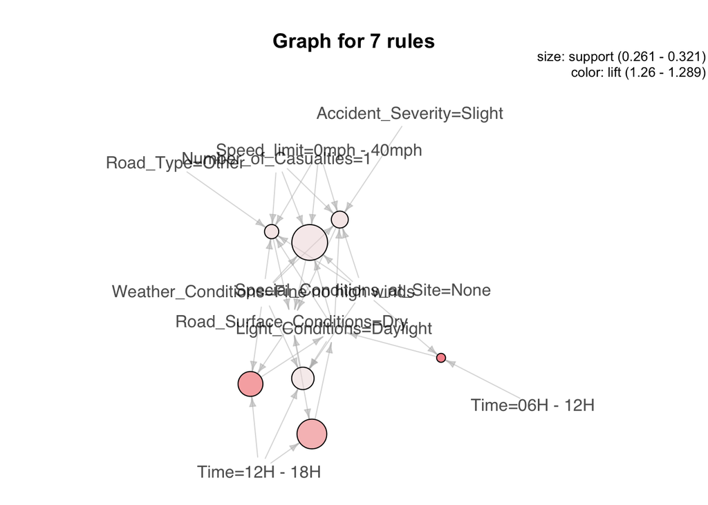

```r
subrules2 <- head(sort(rules, by="lift"), 7)
plot(subrules2, method="graph")
```

#### Conclusion

##### 10 Random Rules

```r
tenRandom <- sample(rules, 10)
tenRandom <- sort(tenRandom, decreasing = TRUE, by = "lift")
inspect(tenRandom)
```

```
##      lhs                                        rhs                                       support confidence     lift
## [1]  {Number_of_Casualties=1,
##       Road_Type=Other,
##       Speed_limit=0mph - 40mph,
##       Light_Conditions=Daylight,
##       Weather_Conditions=Fine no high winds,
##       Special_Conditions_at_Site=None}       => {Road_Surface_Conditions=Dry}           0.2731336  0.9127437 1.261262
## [2]  {Number_of_Vehicles=2,
##       Light_Conditions=Daylight,
##       Road_Surface_Conditions=Dry}           => {Weather_Conditions=Fine no high winds} 0.3512952  0.9659566 1.187268
## [3]  {Light_Conditions=Daylight,
##       Road_Surface_Conditions=Dry}           => {Weather_Conditions=Fine no high winds} 0.5531716  0.9653604 1.186535
## [4]  {Accident_Severity=Slight,
##       Road_Type=Other,
##       Speed_limit=0mph - 40mph,
##       Road_Surface_Conditions=Dry,
##       Special_Conditions_at_Site=None}       => {Weather_Conditions=Fine no high winds} 0.3536942  0.9604475 1.180497
## [5]  {Speed_limit=0mph - 40mph,
##       Road_Surface_Conditions=Dry}           => {Weather_Conditions=Fine no high winds} 0.4883689  0.9601072 1.180079
## [6]  {Number_of_Casualties=1,
##       Road_Type=Other,
##       Speed_limit=0mph - 40mph,
##       Weather_Conditions=Fine no high winds,
##       Road_Surface_Conditions=Dry}           => {Special_Conditions_at_Site=None}       0.3413420  0.9893628 1.012741
## [7]  {Accident_Severity=Slight,
##       Number_of_Casualties=1,
##       Road_Type=Other,
##       Weather_Conditions=Fine no high winds,
##       Road_Surface_Conditions=Dry}           => {Special_Conditions_at_Site=None}       0.3557791  0.9865371 1.009848
## [8]  {Number_of_Vehicles=2,
##       Weather_Conditions=Fine no high winds,
##       Road_Surface_Conditions=Dry}           => {Special_Conditions_at_Site=None}       0.4261295  0.9834072 1.006644
## [9]  {Number_of_Casualties=1,
##       Road_Surface_Conditions=Dry}           => {Special_Conditions_at_Site=None}       0.5617896  0.9828493 1.006073
## [10] {Number_of_Casualties=1,
##       Road_Type=Other}                       => {Special_Conditions_at_Site=None}       0.5935197  0.9805485 1.003718
```

RHS- Accident severity = “Serious”

```r
rules_fatal<-apriori(data_set,parameter = list(support=0.02,confidence=0.2,minlen=3),appearance = list(rhs=c("Accident_Severity=Serious"),default="lhs"))
rules_fatal<-rules_fatal[!is.redundant(rules_fatal)]
subrules_fatal <- rules_fatal[quality(rules_fatal)$lift >= 1.1]
subrules_fatal <- head(sort(rules_fatal, by="lift"), 3)
```

```r
inspect(subrules_fatal)
```

```
##     lhs                                  rhs                            support confidence     lift
## [1] {Number_of_Vehicles=1,
##      Light_Conditions=Darkness,
##      Special_Conditions_at_Site=None} => {Accident_Severity=Serious} 0.02069172  0.2239221 1.565108
## [2] {Number_of_Vehicles=1,
##      Speed_limit=>40mph}              => {Accident_Severity=Serious} 0.02027760  0.2235692 1.562642
## [3] {Number_of_Vehicles=1,
##      Light_Conditions=Darkness}       => {Accident_Severity=Serious} 0.02117010  0.2230497 1.559010
```

RHS - Number of casualties = 2

```r
rules_casualties<-apriori(data_set,parameter = list(support=0.02,confidence=0.2,minlen=3),appearance = list(rhs=c("Number_of_Casualties=2"),default="lhs"))
rules_casualties<-rules_casualties[!is.redundant(rules_casualties)]
subrules_casualties <- rules_casualties[quality(rules_casualties)$lift >= 1.1]
subrules_casualties <- head(sort(rules_casualties, by="lift"), 2)
```

```r
inspect(subrules_casualties)
```

```
##     lhs                                  rhs                         support confidence     lift
## [1] {Number_of_Vehicles=3,
##      Special_Conditions_at_Site=None} => {Number_of_Casualties=2} 0.02029188  0.2642001 1.750535
## [2] {Number_of_Vehicles=2,
##      Road_Type=Other,
##      Speed_limit=>40mph}              => {Number_of_Casualties=2} 0.02660364  0.2398301 1.589064
```

RHS - What time?

```r
rules_hour<-apriori(data_set,parameter = list(support=0.01,confidence=0.7,minlen=3),appearance = list(rhs=c("Time=00H - 06H","Time=06H - 12H","Time=12H - 18H","Time=18H - 24H"),default="lhs"))
rules_hour<-rules_hour[!is.redundant(rules_hour)]
subrules_hour <- rules_hour[quality(rules_hour)$lift >= 1.1]
subrules_hour <- head(sort(rules_hour, by="lift"), 4)
```

```r
inspect(subrules_hour)
```

```
##     lhs                                        rhs                 support confidence     lift
## [1] {Day_of_Week=Friday,
##      Road_Type=Other,
##      Speed_limit=0mph - 40mph,
##      Light_Conditions=Darkness,
##      Weather_Conditions=Fine no high winds,
##      Road_Surface_Conditions=Dry,
##      Special_Conditions_at_Site=None}       => {Time=18H - 24H} 0.01004598  0.7347258 3.145238
## [2] {Day_of_Week=Friday,
##      Road_Type=Other,
##      Speed_limit=0mph - 40mph,
##      Light_Conditions=Darkness,
##      Road_Surface_Conditions=Dry,
##      Special_Conditions_at_Site=None}       => {Time=18H - 24H} 0.01056006  0.7321782 3.134332
## [3] {Day_of_Week=Friday,
##      Road_Type=Other,
##      Speed_limit=0mph - 40mph,
##      Light_Conditions=Darkness,
##      Weather_Conditions=Fine no high winds,
##      Road_Surface_Conditions=Dry}           => {Time=18H - 24H} 0.01012452  0.7316821 3.132209
## [4] {Accident_Severity=Slight,
##      Day_of_Week=Friday,
##      Speed_limit=0mph - 40mph,
##      Light_Conditions=Darkness,
##      Weather_Conditions=Fine no high winds,
##      Road_Surface_Conditions=Dry,
##      Special_Conditions_at_Site=None}       => {Time=18H - 24H} 0.01004598  0.7297718 3.124031
```

RHS - Number of Vehicles = 3

```r
rules_vehicles<-apriori(data_set,parameter = list(support=0.01,confidence=0.1,minlen=3),appearance = list(rhs=c("Number_of_Vehicles=3"),default="lhs"))
rules_vehicles<-rules_vehicles[!is.redundant(rules_vehicles)]
subrules_vehicles <- rules_vehicles[quality(rules_vehicles)$lift >= 1.1]
subrules_vehicles <- head(sort(rules_vehicles, by="lift"), 2)
```

```r
inspect(subrules_vehicles)
```

```
##     lhs                                        rhs                       support confidence     lift
## [1] {Road_Type=Single
## carriageway,
##      Speed_limit=>40mph,
##      Light_Conditions=Daylight,
##      Weather_Conditions=Fine no high winds} => {Number_of_Vehicles=3} 0.01013166  0.1654618 2.094533
## [2] {Accident_Severity=Slight,
##      Road_Type=Single
## carriageway,
##      Speed_limit=>40mph,
##      Light_Conditions=Daylight}             => {Number_of_Vehicles=3} 0.01043868  0.1646211 2.083891
```

RHS - Accident severity = “Slight”

```r
rules_slight<-apriori(data_set,parameter = list(support=0.03,confidence=0.9,minlen=3),appearance = list(rhs=c("Accident_Severity=Slight"),default="lhs"))
rules_slight<-rules_slight[!is.redundant(rules_slight)]
subrules_slight <- rules_fatal[quality(rules_slight)$lift >= 1.1]
subrules_slight <- head(sort(rules_slight, by="lift"), 3)
```

```r
inspect(subrules_slight)
```

```
##     lhs                                        rhs                           support confidence     lift
## [1] {Number_of_Vehicles=2,
##      Number_of_Casualties=2,
##      Speed_limit=0mph - 40mph,
##      Light_Conditions=Daylight}             => {Accident_Severity=Slight} 0.03893443  0.9190966 1.087186
## [2] {Number_of_Vehicles=2,
##      Number_of_Casualties=2,
##      Speed_limit=0mph - 40mph,
##      Weather_Conditions=Fine no high winds,
##      Road_Surface_Conditions=Dry}           => {Accident_Severity=Slight} 0.03784201  0.9163209 1.083903
## [3] {Number_of_Vehicles=2,
##      Number_of_Casualties=2,
##      Speed_limit=0mph - 40mph,
##      Road_Surface_Conditions=Dry}           => {Accident_Severity=Slight} 0.03933427  0.9161816 1.083738
```

We hope that our mining help others to find interesting patterns that can help to decrease the Accident’s rate in the United Kingdom. We’ve felt some dificulties due to larger data information available but at the end we think that we’ve done a good work. We would like also to thank to our teacher for the assistance provided during this assignment.